# Lab 1: Intro to R

Professor Erin Hestir | ES 207 Spring 2021

# Overview

In this lab we will focus on setting up R, RStudio, and R Markdown

R is a command-line interface that forces you to program your own analyses in a script. While this can be intimidating at first, it pays quickly to learn how to script your analyses when you have to redo your analysis if you discover a mistake, provide documentation, transparency and reproducibility of analyses, perform similar workflows, or perform batch processing.

RStudio is a free and open-source integrated development environment for R, a programming language for statistical computing and graphics.

## Don’t Panic

On the surface, this homework assignment and your next one appears long with a lot of homework questions. **Don’t freak out!** Consider this your crash course in learning R as a programming language. It is a little like when you took a foreign language in high school, and the first couple of weeks you spent all your time memorizing vocabulary and conjugations. This is what we are doing here. Take your time, and go through all of the steps. Make sure you can answer all of the questions, and the logic behind it makes sense. If you can get comfortable with the material in this lab, you will soon be ready to start analyzing real data with R!

## How These Tutorials Work

Because we are working with open source software, there are far more useful and varied examples online than we can possibly cover in this class. Part of learning open source software is by reading different tutorials, blog posts, and other resources. I will post required and suggested reading, but you should consider these as springboards only. With a little bit of internet research, you can achieve far more than what these basic tutorials cover.

Sometimes I will give you instruction and examples in these tutorials, and sometimes I will point you to other online tutorials that you will have to complete. Note the learning objectives for each tutorial. These will be part of the overall course objectives, and **will be covered in exams.**

## Homework Assignments

It is important that you knit your notebooks before turning them in - this demonstrates to me that your code works. If you are absolutely stuck and cannot get your code to work, comment out the code so I can still see your attempt. Or better yet, set `eval = FALSE` for the specific code chunk you are having trouble with.

In each section, if the text is

> CRIMSON like this it indicates a prompt for a question that you *must* answer or a product you must turn in for your lab assignment. Crimson blocks of text are action items for you!

# Objectives

After this lab, you will:

- Have the majority of software for this class installed and ready to use it.
- Know the basics of R, and RStudio
- Get in-program help
- Install a `R` package
- Understand what RMarkdown is and why you should use it
- Export an RMarkdown file into many file formats

## R

Make sure you have the most recent install from here: https://cran.r-project.org/

## RStudio

RStudio is one of several integrated development environments (IDEs), which provide convenient editors specialized in writing and executing R code. While it is not necessary to use R with an IDE, it makes scripting a lot easier. Consider this analogy: It is entirely possible to write your thesis in a basic text editor like Notepad or Microsoft Wordpad. However, it is much easier to write your thesis in a software like Microsoft Word, which provides functions like being able to control your page margins, font type and style, and providing basic spelling and grammar checks on your writing. Using an IDE for R provides similar functionality, plus much more, such as debugging, version control, webpage publication, and more (for example, these .html tutorials were all produced using RStudio).

Make sure you have the most recent install here:

https://rstudio.com/products/rstudio/download/#download

Another free option is Eclipse http://www.eclipse.org, to be used with the Eclipse-based StatET plug-in http://www.walware.de/goto/statet. Eclipse allows you to seamlessly move between multiple different scripting languages such as Java, Python, and R.

For the purposes of this class, we will use RStudio.

# Introduction to R

## Launch RStudio.

When you launch the IDE, it will launch an instance of R. The upper left panel shows the script editor where you write your code, with the command line below and on the right are several tabs that list your files, plots, R help packages and the package manager.

Code from the script editor can be sent to R using the *Run* button or by pressing CRTL+ENTER. Only the current line or highlighted parts are sent to R to be executed.

We want to use R to create code and a workflow that is more reproducible. With scripting, we can document everything we do! In science, our end goal isn’t just to analyze stuff, but to do it in a way that anyone can easily and precisely replicate our workflow and results. This includes ourselves in 3 months when our adviser asks us to check something, or our paper reviews come back!

## Your First R Session

In R’s console window, you will type next to the **>**. Use the mouse to click there and hit ENTER.

Type the following command:

```r
x<-c(1,2,4)
```

`x` is a variable, or in R parlance, an **object**. `<-` is the **assignment** operator. Object names cannot contain spaces. The *result* of the operation on the right hand side of `<-` is **assigned** to an **object** with the name specified on the left hand side of the`<-`. The result can be any type of R object, including your own functions (to come later!)

`c()` means “concatenate”, i.e. it merges the numbers into a single **vector**. The parentheses, in this context, refer to a **function**. The function name is “c” and the inputs are the things that are inside of the parentheses.

The `#` sign you see here means ‘comment’. Anything after it is ignored by R. The `##` sign shows a result from the R console.

One of the great things about R is that you can print any variable by just typing it and hitting enter.

Do this now:

```r
x
```

```
## [1] 1 2 4
```

This is very similar to the `print()` statement:

```r
print(x)
```

```
## [1] 1 2 4
```

You should see: `[1] 1 2 4`

Individual vector elements are accessed using `[ ]`, where [1] would be the first element, `[2]` the second, and so on…

Now, type:

```r
x[3]
```

```
## [1] 4
```

This is what is known as a subscript" or **index**. We can also do a subset. Type:

```r
x[2:3]
```

```
## [1] 2 4
```

This asks R to print out the 2nd through the 3rd value in `x`. `:` is known as the **colon operator** and is also a function.

We can concatenate vectors into a new, larger vector. Try:

```r
q <- c(x,x,8)
```

Let’s do some simple statistics like calculating the mean and standard deviation of x. Type:

```r
# Mean of the x vector
mean(x)
```

```
## [1] 2.333333
```

```r
# Standard deviation of the x vector
sd(x)
```

```
## [1] 1.527525
```

Notice these commands print the values out. When you do an assignment `x <- ...` R will NOT print the values out. But the assignment allows us to preserve the output as a new variable. Try:

```r
y <- mean(x)
# And then print it by:
y
```

```
## [1] 2.333333
```

# Installing Packages

Before we delve further into `R`, it’s time to install our first “add-on” package for `R`. Packages are found from a few major repositories, the largest is `CRAN`: http://cran.r-project.org/ Packages are installed in a specific directory (or directories), but are generally not loaded at startup to save memory space and deal with potential cross-package problems that pop up from time to time. To see what is currently LOADED:

```r
?path.package
path.package() # These are the default packages that are loaded by R.
```

```
## [1] "/Library/Frameworks/R.framework/Versions/4.0/Resources/library/stats"
## [2] "/Library/Frameworks/R.framework/Versions/4.0/Resources/library/graphics"
## [3] "/Library/Frameworks/R.framework/Versions/4.0/Resources/library/grDevices"
## [4] "/Library/Frameworks/R.framework/Versions/4.0/Resources/library/utils"
## [5] "/Library/Frameworks/R.framework/Versions/4.0/Resources/library/datasets"
## [6] "/Library/Frameworks/R.framework/Versions/4.0/Resources/library/methods"
## [7] "/Library/Frameworks/R.framework/Resources/library/base"
```

If you have already installed a package (e.g. “MASS”), you simply use the library() function:

```r
?library
library("MASS") # Note that the quotes, in this case, are not actually required.
```

If you want to install a package that you don’t currently have, you will use: `?install.packages` `install.packages()`

With no parameters, you will probably first be asked to pick a CRAN mirror. Choose one that is nearby-ish. Next, you will see a list of packages that are available through CRAN. Scroll down and find `tidyverse`. Click it, and click `OK`. You will see it download and install.

Note that if you already know the name of the package, you can avoid the long list and simply do: `install.packages("tidyverse")`. In this case, quotes are required.

You can get an overview of the package info as well as available functions by:

```r
library(help="ggplot2")
```

You can also see the main help page for the package by:

```r
help(package="ggplot2")
```

If the package is NOT loaded yet, the shortcut for help require an additional parameter. Try typing: `?geom_scatter` to obtain help for a function that is in the ggplot2 package.

Notice this doesn’t work. Try instead: `help("geom_scatter",package = ggplot2)`

If we load the library (do this now, we are going to use it): `library("ggplot2")` we no longer need to specify `package = ggplot2`:`?geom_scatter` should now work.

Verify the package is loaded:

```r
path.package()
```

```
## [1] "/Library/Frameworks/R.framework/Versions/4.0/Resources/library/MASS"
## [2] "/Library/Frameworks/R.framework/Versions/4.0/Resources/library/stats"
## [3] "/Library/Frameworks/R.framework/Versions/4.0/Resources/library/graphics"
## [4] "/Library/Frameworks/R.framework/Versions/4.0/Resources/library/grDevices"
## [5] "/Library/Frameworks/R.framework/Versions/4.0/Resources/library/utils"
## [6] "/Library/Frameworks/R.framework/Versions/4.0/Resources/library/datasets"
## [7] "/Library/Frameworks/R.framework/Versions/4.0/Resources/library/methods"
## [8] "/Library/Frameworks/R.framework/Resources/library/base"
```

# R Markdown

R Markdown allows you to create documents that record your data analysis. This is a critical component of well-designed and responsibly conducted research. Without thorough documentation of your analysis, your research is not reproducible. R Markdown presents your code and its outputs (graphs, statistics) alongside with conventional text explaining your methods and interpreting the results. It is kind of like a traditional lab notebook, but for your code.

Almost all of the documents in this class, including this homework, the syllabus, many of the lecture slides and external online tutorials are made with R Markdown!

## Introduction to R Markdown

A great tutorial for using R Markdown can be found here https://ourcodingclub.github.io/tutorials/rmarkdown/

Work through the *Getting Started with R Markdown* tutorial from the **Coding Club**. It is important that you get RMarkdown running, since you will need to complete the rest of your homework in R Markdown.

> 1. Complete the remaining homework below as a well-commented and easy to follow R Markdown notebook with approriate accompanying text. Turn this in as a .html document. Call it “yourlastname_hw1.html”.

# Coding Etiquette

Another great tutorial from the coding club is on coding etiquette and style. This matters a lot, because if your code is clean and follows good etiquette, it will be easier for you to read, and easier for others to read. Please take a look at this tutorial here:

https://ourcodingclub.github.io/tutorials/etiquette/

Try your best to follow these rules for this class. Like anything else, it takes time and practice.

# Obtaining Help in R

All functions come with a help screen. These help screens are very handy, as they provide information on what the function does, how it works, and usually sample examples at the very bottom. You can use `help()`, or simply `??()`.

```r
# call up a help search
help.start()
```

```
## starting httpd help server ... done
```

```
## If the browser launched by '/usr/bin/open' is already running, it is
##     *not* restarted, and you must switch to its window.
## Otherwise, be patient ...
```

```r
# documentation for a package
??ggplot2
# help for a function
?sum()
```

Sometimes we have some weird characters/functions we want to get help for, for instance try typing:

`?for`

Oops, now we’ve started a for loop. Go ahead and force an error by typing:

`{}`

We can use quotes for functions that don’t behave well with the help command:

```r
?"for"
```

also, our modulo operator causes a similar problem:

```r
# ?%% # doesn't work, but:
?"%%" # does.
```

All this is fine if we know the name of the function, but what if we don’t know what function to use for something, e.g. to determine a multivariate normal distribution? We use `help.search()`

```r
help.search("multivariate normal")
```

or the shortcut ??

```r
??"multivariate normal"
```

Notice it found the `mvrnorm()` function, in the package `MASS`. The help documentation is not perfect. But, R is ever changing, so learning how to use the help is key to keeping up with user contributions and applying them to your analyses!

> 2. Using the help documentation, provide an alternative useage for the function `ncol()`

> 3. Using the help documentation, briefly describe the difference between `read.csv` and `tidyverse::read_csv`. Type your answer as html text in your R Markdown document (see below).

# Some Basic Operations in R

You can get ar input by simply typing in some mathematical statements to evaluate:

```r
1+1
```

```
## [1] 2
```

```r
24/12
```

```
## [1] 2
```

```r
100^2
```

```
## [1] 10000
```

You can also make R recognize words. If you want R to recognize something you type as text, you must enclose it in quotes.

```r
#Make R write some words
paste("Remote","Sensing","is","covered","in","awesomesauce!")
```

```
## [1] "Remote Sensing is covered in awesomesauce!"
```

Here, the `paste()` function works similarly to the concatenate function `c()`. Paste converts the arguments (the words in quotes) to character strings and then concatenates them.

> 4. Can you make R write your name? Print the results to confirm that it worked.

Of course, R is an object based language, so that means we can perform operations on objects we have assigned values to

```r
#Assign R objects
a <- 1+1
b <- 24/12
c <- 100^2
#Perform some math on the objects
d <- (a+c)/b
#Print the results
d
```

```
## [1] 5001
```

*Typing Tip: If you are using RStudio, you can use a keyboard shortcut for the assignment operator.* Windows/Linux: “Alt” + “-” or in Mac: “Option” + “-”

## Code & Comments in R

Everything you type into an R script is a code unless you tell it otherwise. Anything to the right of `#` is ignored by R. Use these comments within the code to describe what it is that you are coding. A good rule of thumb is to always comment liberally in your scripts. This will help you when you return to it and will also help other understand your scripts and analyses.

Comments are important, and part of your grade will based on clear commenting of your code, so use it frequently. On the same line, you can include a comment, remember everything AFTER the pound sign will be ignored, so:

```r
# print out y
print(y)
```

```
## [1] 2.333333
```

Will do the same thing as:

```r
y
```

```
## [1] 2.333333
```

But the former line lets me know, in English, what it is doing.

## List All Objects in the Environment

Some functions are the same as in other languages. These might be familiar to you if you have ever worked with command line. Use`ls()`: to list objects in your current environment. Use `rm()`: remove objects from your current environment.

Give them a try:

```r
# assign value 100 to object "m"
m <- 100
# list objects in my current environment
ls()
```

```
## [1] "a" "b" "c" "d" "m" "q" "x" "y"
```

```r
# remove m
rm(m)
```

> 5. What objects are left in your R session after removing `m`?

Now try removing all of your objects

```r
#remove all objects
rm(list = ls())
ls()
```

```
## character(0)
```

using `rm(list=ls())`, you combine several functions to remove all objects. If you type `x` on the console now you should get `Error: object 'x' not found`.

## A Little Deeper into R

Many R “packages” contain sample datasets, which we can list by:`data()`

Scroll through the list to see what sample datasets are available.

Let’s take a look at the Nile dataset. Print the Nile dataset by typing:

```r
Nile
```

```
## Time Series:
## Start = 1871
## End = 1970
## Frequency = 1
##   [1] 1120 1160  963 1210 1160 1160  813 1230 1370 1140  995  935 1110  994 1020
##  [16]  960 1180  799  958 1140 1100 1210 1150 1250 1260 1220 1030 1100  774  840
##  [31]  874  694  940  833  701  916  692 1020 1050  969  831  726  456  824  702
##  [46] 1120 1100  832  764  821  768  845  864  862  698  845  744  796 1040  759
##  [61]  781  865  845  944  984  897  822 1010  771  676  649  846  812  742  801
##  [76] 1040  860  874  848  890  744  749  838 1050  918  986  797  923  975  815
##  [91] 1020  906  901 1170  912  746  919  718  714  740
```

We can plot this dataset by:

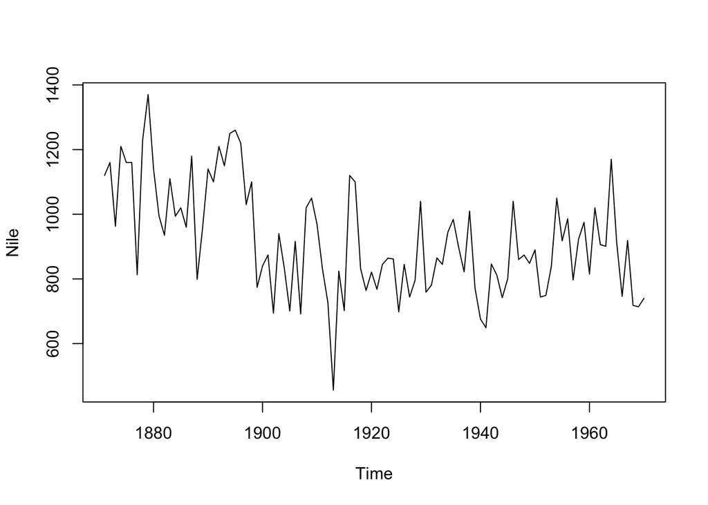

```r
plot(Nile)
```

This is a “time series” dataset (don’t worry about what that means for now), but we can do basic stats on it:

```r
meanNile <- mean(Nile)
meanNile
```

```
## [1] 919.35
```

```r
sdNile <- sd(Nile)
sdNile
```

```
## [1] 169.2275
```

R has advanced plotting and statistical analysis, so let’s create a histogram of this dataset:

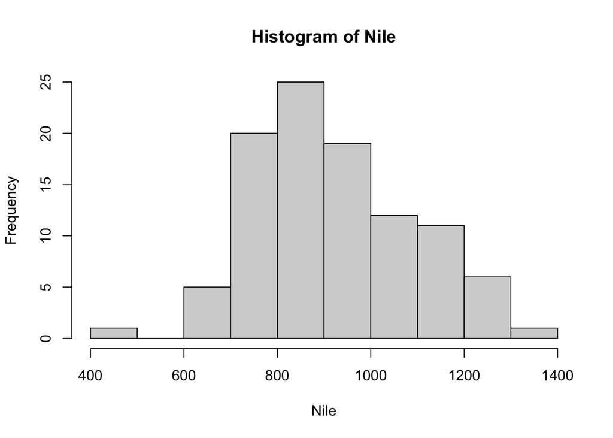

```r
hist(Nile)
```

## Quitting an R session

Now let’s quit R “properly” – this command works on any OS:

`q()`

You will be prompted to `Save workspace image? [y/n/c]:` Select no by typing `n` or click it.  
If you click `yes` (or type `y`) when you next open R, all of your datasets will re-load.

In general, I *strongly* recommend **NOT** saving your workspace. Read this short blog post here to find out why: https://www.r-bloggers.com/2017/04/using-r-dont-save-your-workspace/

Also, in my past experience, having a lot of saved workspace files creates tmp files in your computer which leads to buggy behavior in RStudio in the future - the only fix for which is a complete wipe and fresh install. This is painful and takes a lot of time and hunting through hidden directories.

To disable this option:

- With RStudio running, choose Tools > Global Options from the menus.
- In the Options dialog, change the value for Save workspace to . RData on exit to Never.
- Click OK to apply the change and close the dialog.

# Introduction to functions

Functions are the core of R – in the previous step, we used multiple functions, including `c()`, `mean()`, `sd()`, `data()`, `hist()` and even `q()`

Functions will always have parentheses which are used to pass parameters (some functions don’t have parameters or don’t need them, like `q()`.

Using and *writing* functions is a key part of learning any programming language. We’ll do a quick introduction here.

Boot R back up again. We didn’t save our variables, so try:

```r
meanNile
```

Now we are going to define a function.With all functions, we need to consider the following:

- What are the inputs?
- How does the function manipulate the inputs?
- What are the outputs that will be returned?

We are going to define a function that does the following:

- Input: a vector of values
- Output: a count of the number of odd values in the vector

Type the following in CAREFULLY. Hit enter at the end of each line.A couple of things to note:

- The brackets demarcate the beginning `{` and end `}` of a function or operator
- You will notice that until you finish typing the function in you will see a `+` instead of a `>`. This `+` is what is called a “line continuation character” and is a reminder that you haven’t finished the function (with the end brace).

```r
oddcount <- function(x)
{
    k <- 0 # assign 0 to k
    for (n in x) {
        if(n %% 2 == 1)
        {
            k <- k+1 # %% is the modulo operator
        }
    }
  return(k)
}
```

If you get any errors, make sure you have a `>` and re-type the function until you don’t get an error. Very common errors are not closing parentheses and braces. We will use tools later on to help with that.

Use the tab key to create the spacing. Tabs are not needed, but are key parts of keeping code readable.

Now we have defined the function oddcount. Notice that the **header** of the function tells us there is one input, `x`. Recall that the input must be a vector, which we can create using `c()`. If you want to print the code of the function again, just type:

```r
# don't use parentheses!
oddcount
```

```
## function(x)
## {
##  k <- 0 # assign 0 to k
##  for (n in x) {
##      if(n %% 2 == 1)
##      {
##          k <- k+1 # %% is the modulo operator
##      }
##  }
##   return(k)
## }
```

Now, let’s try the function out by passing it a parameter:

```r
oddcount(x <- c(1,3,5))
```

```
## [1] 3
```

There are three odd numbers in this vector.

Try:

```r
oddcount(x <- c(1,2,3,7,9))
```

```
## [1] 4
```

> 6. How many odd numbers were in this vector?.

The function appears to be working, now let’s look more carefully at what it is doing.

Following the *flow* of a function is a critical skill for understanding what it is doing (and fixing problems that may arise).

First, let’s look at the modulo operator “%%”. This operator returns the remainder of a division, e.g.:

```r
38 %% 7
```

```
## [1] 3
```

Notice that if the modulo of an even number divided by 2 is 0:

```r
38 %% 2
```

```
## [1] 0
```

And an odd number is 1:

```r
39 %% 2
```

```
## [1] 1
```

We’ll learn more about for loops later on, but for now, `for(n in x) { ... }` can be interpreted as setting `n` equal to `x[1]`, running the commands inside of the braces,and then once it is done, repeating the process on `x[2]`, and so-on until it gets to the end of `x`.We can see this by typing:

```r
y <- c(3,0,7)
for(n in y) { print(n) } # Print simply prints the value of the variable
```

```
## [1] 3
## [1] 0
## [1] 7
```

This is the same as:

```r
n <- y[1]
print(n)
```

```
## [1] 3
```

```r
n <- y[2]
print(n)
```

```
## [1] 0
```

```r
n <- y[3]
print(n)
```

```
## [1] 7
```

Anyways, back to our oddcount function:

The function starts with k set to 0, and then starts the loop: `for (n in x) { if(n %% 2 == 1) k <- k+1 # %% is the modulo operator }`

`x` was passed to the function as e.g.: `oddcount(x <- c(1,3,5))`, so `x` is `c(1,3,5)`

The loop starts with `n <- x[1]`, then tests whether or not `n` is odd by checking if `n %% 2` is equal (`==`, note the TWO equal signs) to 1.

Logical statements are used frequently, so let’s see what `if()` is actually testing by typing:

```r
37 %% 2
37 %% 2 == 1
38 %% 2
38 %% 2 == 1
```

[output not shown]

It appears that an `if()` statement, fundamentally, is just testing whether a statement is `TRUE` or `FALSE`.

So, if `n %% 2` *does* equal 1, the function adds `1` to `k`, and repeats the process on `x[2]`, and so on.

Once the function is done, we want to return the value of `k` which is keeping track of how many odd numbers are in our vector, so we use the `return()` statement:`return(k)`

### Function definitions:

In the function definition, `x` is the “formal argument” or **formal parameter** of function oddcount `c(1,3,5)` is the **actual argument** of the function.

Another note: functions can only return a SINGLE variable. If we want to return a lot of things, we’ll use some tricks discussed later.

A lot of times it is helpful to see, more specifically, what a function is doing by using `print()` statements.

`paste()` merges the contents together into a single string.

We will modify the code a bit to help watch the function run:

```r
oddcount <- function(x) {
#   print("x is:")
    print(x)
    k <- 0 # assign 0 to k
    print(paste("k is initialized as",k))
    for (n in x) {
        print(paste("current x value being tested is",n))
        if(n %% 2 == 1)
        {
            k <- k+1 # %% is the modulo operator
            print(paste(n,"is an odd number!"))
        } else
        {
            print(paste(n,"is an even number!"))
        }
        print(paste("k is currently",k))
    }
    print(paste("The final k is",k))
    return(k)
}
# And trying running our more verbose function:
oddcount(x <- c(1,2,3,7,9))
```

```
## [1] 1 2 3 7 9
## [1] "k is initialized as 0"
## [1] "current x value being tested is 1"
## [1] "1 is an odd number!"
## [1] "k is currently 1"
## [1] "current x value being tested is 2"
## [1] "2 is an even number!"
## [1] "k is currently 1"
## [1] "current x value being tested is 3"
## [1] "3 is an odd number!"
## [1] "k is currently 2"
## [1] "current x value being tested is 7"
## [1] "7 is an odd number!"
## [1] "k is currently 3"
## [1] "current x value being tested is 9"
## [1] "9 is an odd number!"
## [1] "k is currently 4"
## [1] "The final k is 4"
```

```
## [1] 4
```

> 7. Try creating a new function “evencount” that counts the even numbers in a vector. Turn in your script as a .R script. Make sure you add appropriate comments - you will be graded on this.

# Directory Structures

Having a logical, consistent directory structure is an important component of every project inside this class, your other classes, your thesis, and life beyond your thesis. Again, when we do science, we are not just doing stuff, we are performing reproducible analyses. You need to layout your work, save different steps of your work, and be able to find it again in logical places.

I will not dictate to you how to set up your directory structures for this class. Everyone’s brain works a little bit differently when it comes to logical organization. Sometimes if you work on large, collaborative projects, they WILL dictate these structures. For good reason (again, science is about documentation, reproducibility, and sharing). For the purposes of this class, find something that works for you and stick with it.

## Making good directory layouts

Before you set something up, read the following blog posts (yes, this is part of your homework!)

- On good directory layout: https://nicercode.github.io/blog/2013-04-05-projects/
- On what RStudio offers for projects and version control: https://support.rstudio.com/hc/en-us/articles/200526207-Using-Projects

> 8. What are the three main reasons you want to have a good project layout? Can you think of any others?.

> 9. What are the three primary principles to follow in a good project layout?

## Full, base, and relative paths

The **full path** is the complete directions for how to find the desired directory or file. It *always* starts with the home directory or root (e.g., `C:\Users\CardiB\`). A full path is the **base path** when used to set the working directory to a specific directory. So in this class, Cardi B set up her directory layout so that her **full path** looks something like this: `C:\Users\CardiB\classes\ES207\Rscripts\lab1`. If Cardi B wanted to set a smart **base path** for his working directory (see below), it might look something like this: `C:\Users\CardiB\classes\ES207`.

*Note!* File or directory paths and the home directory look different on different operating systems. Linux will look something like this: `/home/CardiB`. Windows will look like the examples above: `C:\Documents and Settings\CardiB` or `C:\Users\CardiB`. Mac OS X and Unix look like this: `/Users/CardiB/`. The format will vary depending on what version of windows you are running. *NOTE* the direction of the slashes. I use a Mac, so get used to seeing examples following that structure, and make sure you adjust your paths according to your own operating system.

> 10. Write out the full path for your R installation. Use the format of the operating system you are currently using.

> 11. Write the path above using a different operating system.

A relative path is a path to a directory or file that starts from the location determined by the working directory. So, if our working directory is set to `/Users/CardiB/classes/ES207`, we can create a relative path for all directories and files within the `ES207` directory.

> 12. Write out the **full path** for the directory structure you have set up for this class all the way to where you have saved this .html tutorial.

> 13. Write out the **relative path** for this .html file assuming your working directory to be set to your equivalent of `Users/CardiB/classes/`.

> 14. Write out the paths in an operating system other than your own.

## The R working directory

In `R`, the working directory is the directory where are will look for any file to open and where it save any output.

Without a working directory, all of your `R` scripts would need a full file path written out every time you want to open or save a file. It is much more efficient to set a **base file path** as our **working directory** and then all the file paths in our scripts are just the file path relative to that base path (this is known as a **relative path**).

### Find a full path to a file in an unknown location

Oh no! What if you can’t figure out the file path to this .html file you downloaded?

- Windows: Right click on file, select Properties, go to the General tab, or in the file path bar at the top of each navigator window.
- Mac OS X: Right click or CRTL+click on the file, select **Get Info**

### Determine current working directory

Once we are in `R`, we can view the current working directory using `getwd()`

```r
getwd()
```

```
## [1] "/Users/ehestir/ncsu_laptop/teaching/207_s21/homework"
```

### Set the working directory

To set our current working directory to the location where our data are located, we can use `R` script, or we can use the RStudio GUI.

```r
#setwd('/Users/ehestir')
getwd()
```

```
## [1] "/Users/ehestir/ncsu_laptop/teaching/207_s21/homework"
```

To view the file contents and sub directories of your working directory:

```r
list.files()
```

```
## [1] "data"
## [2] "hw_01_intro_to_R_and_RMarkdown_files"
## [3] "hw_01_intro_to_R_and_RMarkdown.html"
## [4] "hw_01_intro_to_R_and_RMarkdown.Rmd"
```

You can also set the working directory using the RStudio GUI by navigating to `Session` > `Select Working Directory` > `Choose Directory`.

Note that using either method, you will be able to see the contents of the current working directory in the Files pane of the RStudio GUI (to your right).

# Reading in Data

We can read in external data using the `tidyverse`, which has many advantages over base R functions.

Here we are going to read in water quality monitoring data from the western basin of Lake Erie, where the Great Lakes Environmental Research Laboratory of the U.S. National Oceanic and Atmospheric Administration (NOAA-GERL). They routinely monitor the basin from May to October every year. The data file `LakeErie1.csv` includes data up to the end of 2014.

These data come from Qian’s Environmental and Ecological Statistics text. You can clone the repo from GitHub here: https://github.com/songsqian/eesR.git

Make sure to download the data and place them in your well-organized project structure. Then, read the data using the `tidyverse::read_csv`.

```r
# loading the necessary package for the read_csv function
library(tidyverse)
# make sure you point to the directory where the data are located.
erie <- read_csv("data/eesR/R/Data/LakeErie1.csv")
# print the result for a sanity check
erie
```

```
## # A tibble: 730 x 41
##    Station  Year Day   Date  Time  Latitude Longitude Depth Secchi  Temp   Co0
##    <chr>   <dbl> <chr> <chr> <tim>    <dbl>     <dbl> <dbl>  <dbl> <dbl> <dbl>
##  1 LE1      2008 26-J… 6/26…    NA     41.8      83.1    NA    3.4    NA    NA
##  2 LE2      2008 26-J… 6/26…    NA     41.8      83.2    NA    4.9    NA    NA
##  3 LE3      2008 26-J… 6/26…    NA     41.8      83.4    NA    3.2    NA    NA
##  4 LE4      2008 26-J… 6/26…    NA     41.7      83.4    NA    2.2    NA    NA
##  5 LE5      2008 26-J… 6/26…    NA     41.7      83.5    NA    0.2    NA    NA
##  6 LE6      2008 26-J… 6/26…    NA     41.7      83.3    NA    1.4    NA    NA
##  7 LE7      2008 26-J… 6/26…    NA     41.7      83.2    NA    2.4    NA    NA
##  8 LE8      2008 26-J… 6/26…    NA     41.8      83.3    NA    1.9    NA    NA
##  9 LE9      2008 26-J… 6/26…    NA     41.8      83.1    NA    2.5    NA    NA
## 10 LE10     2008 26-J… 6/26…    NA     41.9      83.2    NA    2.4    NA    NA
## # … with 720 more rows, and 30 more variables: SpCo0 <dbl>, BeamAtten <dbl>,
## #   Transmission <dbl>, chla <dbl>, PC <dbl>, PAR <dbl>, DO <dbl>,
## #   au.chl <dbl>, AquaFluor_PC <dbl>, AquaFluor_CHL <dbl>, Turbidity <dbl>,
## #   TP <dbl>, TDP <dbl>, SRP <dbl>, NH4 <dbl>, NO3 <dbl>, SiO2 <dbl>, Cl <dbl>,
## #   TSS <dbl>, VSS <dbl>, POC <dbl>, PON <dbl>, DOC <dbl>, ExChla <dbl>,
## #   ExPC <dbl>, pMC <dbl>, dMC <dbl>, pMC_LC_MS <dbl>, TCyanos_cells <dbl>,
## #   TCyanos_volume <dbl>
```

If we view the data, we can see that `read_csv` is very kind to us. It was able to parse the data very well, filling in blank observations with `NA`, and automatically detecting the site as a character, and most observations as data type `double`.

> 14. Use ggplot to make a scatter plot that visualizes the relationship between chlorophyll-a `chla` and total phosphorous `TP`. Hint - check your R for Data Science text!

If you manage to get the solution to number 14, you will see that `ggplot` is also very nice, because it handles NA’s for you quite well.

> 15. How many observations (rows) have missing `TP` values? Hint - check your R for Data Science text!

If we want to get rid of all rows that have NA’s in our dataset, the `tidyverse` also has a nice `drop_na()` function. Check this out:

```r
?drop_na()
# check the dimensions of our original dataset
dim(erie)
```

```
## [1] 730  41
```

```r
#make a new object that is a result of the old object piped through the drop_na function
erie_no_na <- erie %>%
  drop_na()

# check the dimensions of the new dataset
dim (erie_no_na)
```

```
## [1]  0 41
```

So we are left with no rows - meaning each row had at least one column with a NA value. So, we need to be careful about how to use this function! Probably best to use in combination with `select()` and `filter()`

> 16. Challenge question! Water quality data are often transformed to a log-scale (more about this later). Use the mutate function to create a new variable column for a) TP, and b) pMC. Hint - check your R for Data Science text! Another hint you can’t take the log of zero. What are you going to do? -